# Research-In-Progress

Anish Sanjay Shah, MD/MS  
Cardiology Fellow  
University of Illinois at Chicago

Table 1: Progress updates

|  | Task | Deadline |
| --- | --- | --- |
| Arrhythmia (8.7%) |  |  |
| Atrial Flutter and Family History | Obtain genetic data for exome sequencing | 2023-02-07 |
| Atrial Flutter and Family History | Final data collection on family history needed prior to final analyses | 2023-03-03 |
| Atrial Flutter and Family History | Manuscript revision | 2023-01-23 |
| Atrial Flutter and Family History | HRS abstract submitted on 12/09/22. Accepted on 02/13/23 | 2022-12-09 |
| Atrial Flutter and Family History | Decide on final format and approach for paper | 2023-02-20 |
| Cather Ablation Registry | Results dependent on clinical covariate data collection | 2023-02-13 |
| K23 | Specific aims draft | 2023-02-07 |
| K23 | Manipulate VCF files | 2023-02-07 |
| Computational (1.3%) |  |  |
| Cardiovascular Biorepository | IRB approved | 2023-02-12 |
| Cardiovascular Biorepository | CCTS data pull meeting pending | 2023-03-01 |
| Cardiovascular Biorepository | IRB revisions completed | 2023-02-05 |
| Recurrent Events | v0.1.0 = Reformatting of recurrent event data into different model states | 2023-02-16 |
| Rhythm Analysis | v0.1.0 = LS Pro data intake and visualization | 2022-12-09 |
| Rhythm Analysis | v0.2.0 = Interval detections and peak analysis | 2023-04-01 |
| Clinical (82%) |  |  |
| Clinic | Heart Failure Clinic | 2023-06-30 |
| Clinic | JBVA FIT Clinic | 2023-06-30 |
| Inpatient | JBVA Catheterization Lab | 2023-01-27 |
| Inpatient | UIC Electrophysiology Consults | 2023-02-10 |
| Inpatient | JBVA Echocardiography Lab | 2023-02-24 |
| Epidemiology (5.9%) |  |  |
| F32 | RPRR for Year 1 | 2022-10-31 |
| F32 | Obtain working dataset for current ECG patch data | 2022-02-13 |
| Mental Stress and CV Mortality | Re-discuss strategy with senior authors | 2022-01-10 |
| Mental Stress and CV Mortality | Review key aspects of paper for resubmission. Consider HRV in context of current literature. Evaluate NRI and concordance statistics between models. | 2023-02-13 |
| Mental Stress and CV Mortality | Analysis of non-linearity to use quartile based statistics | 2023-02-23 |

# February 27, 2023

## Updates

- AFL/FH: will need age of diagnosis of event of family history prior to final analyses
- CAR: analysis pending by Konda, however unclear if we can strongly accept null-hypothesis

## Non-linearity in ANS dysfunction

1. Proportional hazard assumptions
   1. Defined using time-variance, time-interaction, Martingale residuals
   2. Satisfied PH assumptions
2. Non-linearity of HRV and CV mortality
   1. Spline analysis with up to 5 knots
   2. Parametric threshold analysis (survival modeling)
   3. Non-parametric (binary outcome) threshold analysis
   4. Identified **non-linearity** of response
3. Re-analyzed data using cut-point (as shown in Figure 1)
   1. Almost 100% accuracy in classifier of low-risk cohort
   2. Almost 10-fold hazard in identify high-risk cohort

[figure not shown]

Figure 1: Increase of ~10 fold in CV mortality in 1/4 patients identified by abnormal resting and reactive vagal tone. Robust classifier of resilience.

## Specific aims

Have revised [aims](http://asshah4.github.io/research/k23/overview.html), and have drafted the x1 page **specific aims** to be shared with mentors.

Mentors: D Darbar, AJ Shah, A Alonso, M McCauley, *A Boyd*

# February 20, 2023

## AFL/FH

- Genetic basis for FH may be more promising than association with FH broadly, but would require additional WES to be sent
- Would need to repeat VCF analysis for an arrhythmia panel (instead of cardiomyopathy panel)

## CBCD

Computational biorepository for cardiovascular disease

- Will need a large computational biorepository
  - Claims data from both CPT/ICD codes
  - Clinical documentation (raw text from clinical notes)
  - Medication history
  - Study data e.g. XML of ECG, echo reports, coronary angiograms, device interrogations, etc
- CCTS to pull data, DRA to be submitted today

Also working on VA research database access, CART-CL reporting data, MVP, ARIC, and UK Biobank as additional large-scale data

# February 6, 2023

## Updates

- AFL/FH: **WES** needed prior to completing revisions
- ARIC: potential option to pursue genetic profiling in ARIC per Alvaro, need formal proposal
- K23: drafting specific aims in 1-pager format
- VCF: data able to be analyzed/cleaned, however requires more CPU to perform

Currently on inpatient service with limited time

[figure not shown]

Figure 2: Chromosome 1 summary

# January 9, 2023

## Updates

AFL/FH:

- Pedigrees/genetics completed (thanks to Ana, Shashank, Mike)
- Outline/draft to be re-written
1. HRV/CV Mortality paper rejected, need to re-think strategy with senior authors
2. K23 aims to include 1) EP lab as translational component, 2) arrhythmia risk prediction as computational component
- Onset
- Adjusted Models
- Individual Risk
- Risk by +/- FH

Predictors of Early Onset Atrial Flutter.

| Characteristics | Overall, N = 921<sup>1</sup> | EO-AFL, N = 240<sup>1</sup> | LO-AFL, N = 681<sup>1</sup> |
| --- | --- | --- | --- |
| Age (years) | 67 (14) | 58 (12) | 71 (13) |
| Male | 560 (61%) | 146 (61%) | 414 (61%) |
| Race |  |  |  |
| Asian | 25 (2.7%) | 5 (2.1%) | 20 (2.9%) |
| Black | 477 (52%) | 154 (64%) | 323 (47%) |
| Hispanic/Latinx | 145 (16%) | 26 (11%) | 119 (17%) |
| Unknown/Mixed | 72 (7.8%) | 21 (8.8%) | 51 (7.5%) |
| White | 202 (22%) | 34 (14%) | 168 (25%) |
| Family History of Arrhythmias | 87 (9.6%) | 31 (13%) | 56 (8.3%) |
| Smoker | 365 (41%) | 101 (44%) | 264 (40%) |
| ETOH Abuse | 248 (28%) | 79 (35%) | 169 (26%) |
| BMI (kg/m^2) | 30 (25, 36) | 32 (27, 38) | 29 (25, 36) |
| Diabetes Mellitus | 368 (40%) | 98 (42%) | 270 (40%) |
| Hypertension | 740 (81%) | 183 (78%) | 557 (82%) |
| Coronary Artery Disease | 220 (24%) | 52 (22%) | 168 (25%) |
| Obstructive Sleep Apnea | 170 (19%) | 54 (23%) | 116 (17%) |
| Cerebrovascular Disease | 122 (13%) | 24 (10%) | 98 (14%) |
| Peripheral Vascular Disease | 52 (5.7%) | 13 (5.5%) | 39 (5.8%) |
| Heart Failure with Reduced Ejection Fraction | 327 (37%) | 92 (41%) | 235 (36%) |

Bolded cells show significant difference between groups. EO-AFL = early onset atrial flutter; LO-AFL = late-onset atrial flutter.  
<sup>1</sup> Mean (SD); n (%); Median (IQR)

Association of Family History and Covariates with Early Flutter

| Covariates | Odds Ratio (95% CI) |
| --- | --- |
| Family History of Arrhythmias | 1.82 (1.08, 3.03) |
| Male | 0.91 (0.64, 1.30) |
| Black Race | 2.12 (1.50, 3.01) |
| Smoker | 0.98 (0.69, 1.38) |
| ETOH Abuse | 1.38 (0.95, 2.00) |
| BMI (SD) | 1.15 (0.97, 1.37) |
| Diabetes Mellitus | 1.25 (0.87, 1.79) |
| Hypertension | 0.55 (0.36, 0.85) |
| Obstructive Sleep Apnea | 1.21 (0.77, 1.88) |
| Beta or Calcium Channel Blockers | 0.46 (0.27, 0.77) |
| Heart Failure with Reduced Ejection Fraction | 1.16 (0.81, 1.64) |

Each covariate expresses an adjusted odds ratio (95% CI) for having Early Onset Atrial Flutter. All terms were included in the model.

Predictors of early onset atrial flutter

| Covariates | Odds Ratio (95% CI) |
| --- | --- |
| Male | 1.00 (0.74, 1.36) |
| Black Race | 1.98 (1.47, 2.70) |
| Family History of Arrhythmias | 1.68 (1.04, 2.66) |
| Smoker | 1.18 (0.87, 1.60) |
| ETOH Abuse | 1.56 (1.12, 2.16) |
| BMI (SD) | 1.28 (1.11, 1.48) |
| Diabetes Mellitus | 1.08 (0.80, 1.46) |
| Hypertension | 0.76 (0.53, 1.09) |
| Coronary Artery Disease | 0.86 (0.60, 1.22) |
| Obstructive Sleep Apnea | 1.44 (1.00, 2.07) |
| Cerebrovascular Disease | 0.67 (0.41, 1.06) |
| Peripheral Vascular Disease | 0.96 (0.48, 1.78) |
| Heart Failure with Reduced Ejection Fraction | 1.23 (0.90, 1.68) |

Each covariate were modeled as independent predictors in logistic regressions. Each estimate is expressed as an unadjusted odds ratio (95% CI) for early onset atrial flutter.

Predictors of Early Onset Atrial Flutter by Family History

| Covariates | No Family History of Arrhythmias | Postive Family History of Arrhythmias |
| --- | --- | --- |
| Male | 0.97 (0.70, 1.34) | 1.12 (0.46, 2.74) |
| Black Race | 2.16 (1.56, 3.02) | 1.45 (0.60, 3.53) |
| Smoker | 1.16 (0.83, 1.60) | 1.02 (0.41, 2.50) |
| ETOH Abuse | 1.64 (1.15, 2.33) | 0.70 (0.26, 1.77) |
| BMI (SD) | 1.24 (1.06, 1.44) | 1.61 (0.99, 2.69) |
| Diabetes Mellitus | 0.99 (0.71, 1.37) | 1.98 (0.81, 4.92) |
| Hypertension | 0.74 (0.51, 1.10) | 0.49 (0.15, 1.58) |
| Obstructive Sleep Apnea | 1.32 (0.88, 1.96) | 2.09 (0.72, 6.09) |
| Beta or Calcium Channel Blockers | 0.39 (0.22, 0.64) | 1.23 (0.29, 4.70) |
| Heart Failure with Reduced Ejection Fraction | 1.29 (0.93, 1.80) | 0.96 (0.35, 2.49) |

Each model expresses an unadjusted odds ratio (95% CI) for having Early Onset Atrial Flutter.

## AFL/genetics

[figure not shown]

AFL/surrogate disease burden

| **Characteristic** | **Genetic Data Available**, N = 18<sup>1</sup> | **Genetic Data Missing**, N = 924<sup>1</sup> |
| --- | --- | --- |
| Age (years) | 71 (13) | 72 (14) |
| Male | 10 (56%) | 638 (69%) |
| Race |  |  |
| Asian | 0 (0%) | 23 (2.5%) |
| Black | 9 (50%) | 343 (37%) |
| Hispanic/Latinx | 8 (44%) | 361 (39%) |
| Unknown/Mixed | 1 (5.6%) | 25 (2.7%) |
| White | 0 (0%) | 172 (19%) |
| Family History of Arrhythmias | 1 (5.6%) | 69 (7.5%) |
| Smoker | 5 (28%) | 503 (56%) |
| ETOH Abuse | 1 (6.2%) | 381 (43%) |
| BMI (kg/m^2) | 33 (25, 37) | 27 (24, 34) |
| Diabetes Mellitus | 9 (50%) | 278 (30%) |
| Hypertension | 15 (83%) | 775 (84%) |
| Coronary Artery Disease | 2 (11%) | 389 (42%) |
| Obstructive Sleep Apnea | 2 (11%) | 338 (37%) |
| Cerebrovascular Disease | 3 (17%) | 327 (36%) |
| Peripheral Vascular Disease | 0 (0%) | 44 (4.8%) |
| Heart Failure with Reduced Ejection Fraction | 9 (53%) | 445 (50%) |

<sup>1</sup> Mean (SD); n (%); Median (IQR)

[figure not shown]

AFL/mutant

Identified Rare and Novel Variants in Probands with Early and Late Onset Atrial Flutter

| Subjects | Gene | Chromosome | Posititon | Variant Identifier | Variation | Classification | Sex | Race/Ethnicity | Co-morbid Conditions |
| --- | --- | --- | --- | --- | --- | --- | --- | --- | --- |
| Late Onset or Mixed |  |  |  |  |  |  |  |  |  |
| UIC0321 | BAG3 | 10 | 119669968 | — | — | Weak Pathogenic | Male | Black | AF, HFrEF |
| UIC0418 | LMNA | 1 | 156138615 | — | — | Weak Pathogenic | Male | Black | AF, HFrEF, DM, HTN |
| UIC0335 | MYH7 | 14 | 23417643 | — | — | Weak Pathogenic | Female | Hispanic/Latinx | AF, DM, HTN |
| UIC0401 | SCN5A | 3 | 38554306 | rs199473278 | — | Weak Pathogenic | Male | Black | AF, CVA, HFrEF, HTN |
| UIC0343 | SCN5A | 3 | 38633283 | — | — | Weak Pathogenic | Female | Black | AF, HFrEF, HTN |
| UIC0380 | TPM1 | 15 | 63042823 | — | Untranslated Region | Weak Benign | Female | Hispanic/Latinx | AF, CVA, DM, HTN |
| UIC0077 | TTN | 2 | 178527235 | rs193212275 | Intron Missense | Benign | Female | Black | AF, HTN |
| UIC0083 | TTN | 2 | 178589206 | — | Intron Missense | Weak Pathogenic | Male | Hispanic/Latinx | AF, HFrEF, DM, HTN |
| UIC0383 | TTN | 2 | 178545822 | — | Intron Missense | Weak Pathogenic | Male | Hispanic/Latinx | HTN |
| UIC0507 | TTN | 2 | 178539042 | rs186405108 | Exon Missense | Weak Pathogenic | Male | Black | AF, HFrEF |
| UIC0100 | TTN | 2 | 178633323 | — | — | — | Male | Hispanic/Latinx | AF, DM, HTN |
| UIC0757 | TTN | 2 | 178558548 | rs368921501 | Intron Missense | — | Female | Black | AF, HFrEF, DM, HTN |
| UIC0530 | TTN | 2 | 178599586 | rs370118111 | — | Weak Pathogenic | Female | Hispanic/Latinx | FH, AF, HTN |
| Early Onset |  |  |  |  |  |  |  |  |  |
| UIC0202 | NEXN | 1 | 77942208 | — | — | Weak Pathogenic | Male | Unknown/Mixed | AF, HFrEF, DM, HTN |
| UIC0078 | TTN | 2 | 178620048 | — | Exon Missense | Weak Pathogenic | Female | Hispanic/Latinx | AF |
| UIC0101 | TTN | 2 | 178774305 | rs374615369 | — | Weak Pathogenic | Female | Black | AF, HFrEF, HTN |
| UIC0142 | TTN | 2 | 178537774 | — | Intron Missense | Weak Pathogenic | Male | Hispanic/Latinx | AF, CVA, DM, HTN |
| UIC0413 | TTN | 2 | 178729079 | — | — | Weak Pathogenic | Male | Black | DM, HTN |

# December 19, 2022

## Updates

AFL/FH:

- Pedigrees TBD
- Draft completed, pending feedback
- Supplemental tables needed?

AF/Recurrence:

- Scott added additional patients from UIC (September 2020 to now)
- Data collection pending

## K23 Aims

Objective: *Clinical EP researcher using computational neurocardiology techniques to study arrhythmia mechanisms*

1. Evaluating vagolysis and its effect on triggered arrhythmia mechanisms, both ventricular (e.g. SCD) and atrial (triggered AF)
2. Using computational approach to phenotype triggered onset arrhythmias, e.g. atrial fibrillation

Mentorship Team: **Amit J. Shah**, **Dawood Darbar**, Rachel Lampert, Viola Vaccarino, Mark McCauley, Andrew Boyd, Alvaro Alonso

## K23 Approach

**Vagal tone and triggered arrhythmias**

**Arrhythmia phenotyping**

## Murine Model of Vagolysis

- Atria are heavily innervated by ANS ganglia
  - Sympathovagal balance locally mediated through adrenergic lysis of cholinergic activity
  - Neuropeptide Y (NPY) causes cholinergic inhibition through Y2R
- Pro-arrhythmic murine model (compared to healthy controls)
  - Ex-vivo vagal-sparing Langendorf preparation
  - Catecholamine infusion and NPY Y2R antagonists to modulate arrhythmic state
- Measure atrial conductive properties as outcome
  - Baseline, with catecholamine infusion, VNS stimulation, and Y2R antagonism

# December 12, 2022

## AF Catheter Ablation and Recurrence

Data/power increase:

- Inclusion of VA data
- Additional data pull from EPIC by Scott Uphouse (pending)
- Inclusion of UIC billing code data?

## Atrial Flutter and Family History

Pedigrees:

- How should these be incorporated into the manuscript?

Genetics:

- 305 patients that have undergone whole exome sequencing, but unclear how to match these to the AFL data
- Should we genotype the rest of the EO-AFL patients?

## ECG/EGM analysis

[figure not shown]

# November 21, 2022

## Updates

- AHA IPA: Completed draft, pending revisions
- AFL Paper: Draft to be done by Wednesday
- AF Ablation + Biorepository: Pending IRB
- Stress and CVD Mortality: Submitted to *Circulation*, revisions Pending

# November 14, 2022

## Early Onset Atrial Flutter

1. Draft of paper expanded to include results
2. Prominent findings of family history and association with arrhythmia
3. Key tables and figures established

### Table: Cohort Descriptions

Predictors of Early Onset Atrial Flutter.

| Characteristics | Overall, N = 921<sup>1</sup> | EO-AFL, N = 240<sup>1</sup> | LO-AFL, N = 681<sup>1</sup> |
| --- | --- | --- | --- |
| Age (years) | 67 (14) | 58 (12) | 71 (13) |
| Male | 560 (61%) | 146 (61%) | 414 (61%) |
| Race |  |  |  |
| Asian | 25 (2.7%) | 5 (2.1%) | 20 (2.9%) |
| Black | 477 (52%) | 154 (64%) | 323 (47%) |
| Hispanic/Latinx | 145 (16%) | 26 (11%) | 119 (17%) |
| Unknown/Mixed | 72 (7.8%) | 21 (8.8%) | 51 (7.5%) |
| White | 202 (22%) | 34 (14%) | 168 (25%) |
| Family History of Arrhythmias | 87 (9.6%) | 31 (13%) | 56 (8.3%) |
| Smoker | 365 (41%) | 101 (44%) | 264 (40%) |
| ETOH Abuse | 248 (28%) | 79 (35%) | 169 (26%) |
| BMI (kg/m^2) | 30 (25, 36) | 32 (27, 38) | 29 (25, 36) |
| Diabetes Mellitus | 368 (40%) | 98 (42%) | 270 (40%) |
| Hypertension | 740 (81%) | 183 (78%) | 557 (82%) |
| Coronary Artery Disease | 220 (24%) | 52 (22%) | 168 (25%) |
| Obstructive Sleep Apnea | 170 (19%) | 54 (23%) | 116 (17%) |
| Cerebrovascular Disease | 122 (13%) | 24 (10%) | 98 (14%) |
| Peripheral Vascular Disease | 52 (5.7%) | 13 (5.5%) | 39 (5.8%) |
| Heart Failure with Reduced Ejection Fraction | 327 (37%) | 92 (41%) | 235 (36%) |

Bolded cells show significant difference between groups. EO-AFL = early onset atrial flutter; LO-AFL = late-onset atrial flutter.  
<sup>1</sup> Mean (SD); n (%); Median (IQR)

### Table: Risk by Family History

Predictors of Early Onset Atrial Flutter by Family History

| Covariates | No Family History of Arrhythmias | Postive Family History of Arrhythmias |
| --- | --- | --- |
| Male | 0.97 (0.70, 1.34) | 1.12 (0.46, 2.74) |
| Black Race | 2.16 (1.56, 3.02) | 1.45 (0.60, 3.53) |
| Smoker | 1.16 (0.83, 1.60) | 1.02 (0.41, 2.50) |
| ETOH Abuse | 1.64 (1.15, 2.33) | 0.70 (0.26, 1.77) |
| BMI (SD) | 1.24 (1.06, 1.44) | 1.61 (0.99, 2.69) |
| Diabetes Mellitus | 0.99 (0.71, 1.37) | 1.98 (0.81, 4.92) |
| Hypertension | 0.74 (0.51, 1.10) | 0.49 (0.15, 1.58) |
| Obstructive Sleep Apnea | 1.32 (0.88, 1.96) | 2.09 (0.72, 6.09) |
| Beta or Calcium Channel Blockers | 0.39 (0.22, 0.64) | 1.23 (0.29, 4.70) |
| Heart Failure with Reduced Ejection Fraction | 1.29 (0.93, 1.80) | 0.96 (0.35, 2.49) |

Each model expresses an unadjusted odds ratio (95% CI) for having Early Onset Atrial Flutter.

### Table: Fully Adjusted Model

Association of Family History and Covariates with Early Flutter

| Covariates | Odds Ratio (95% CI) |
| --- | --- |
| Family History of Arrhythmias | 1.82 (1.08, 3.03) |
| Male | 0.91 (0.64, 1.30) |
| Black Race | 2.12 (1.50, 3.01) |
| Smoker | 0.98 (0.69, 1.38) |
| ETOH Abuse | 1.38 (0.95, 2.00) |
| BMI (SD) | 1.15 (0.97, 1.37) |
| Diabetes Mellitus | 1.25 (0.87, 1.79) |
| Hypertension | 0.55 (0.36, 0.85) |
| Obstructive Sleep Apnea | 1.21 (0.77, 1.88) |
| Beta or Calcium Channel Blockers | 0.46 (0.27, 0.77) |
| Heart Failure with Reduced Ejection Fraction | 1.16 (0.81, 1.64) |

Each covariate expresses an adjusted odds ratio (95% CI) for having Early Onset Atrial Flutter. All terms were included in the model.

### Table: Grouped Forest Plots

Association of Family History with Early Flutter by Subgroups

No.

Estimate

Odds for Early Flutter

black

1

420

1.1 (0.52, 2.4)

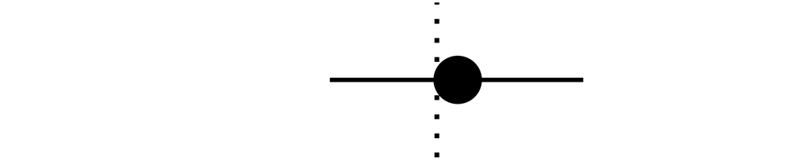

0

390

2.9 (1.4, 5.9)

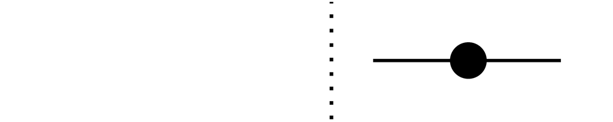

sex

0

330

1.7 (0.75, 3.7)

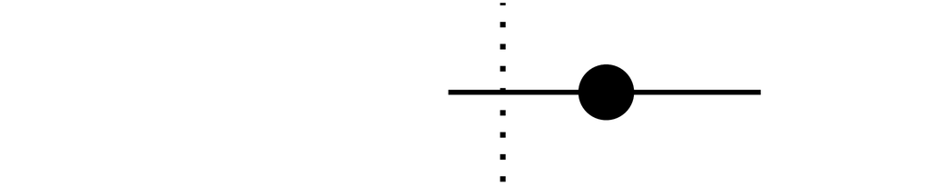

1

480

1.9 (0.91, 3.8)

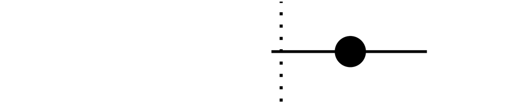

obese

0

570

1.6 (0.83, 3.1)

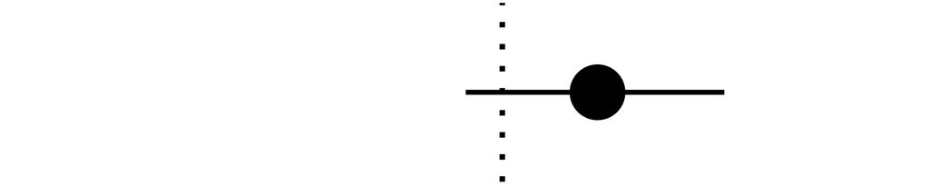

1

240

2.2 (0.91, 5.3)

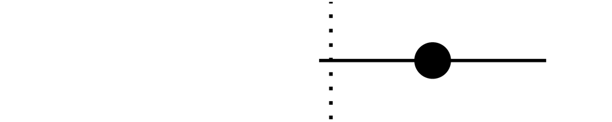

lvef_reduced

0

520

2.2 (1.2, 4.2)

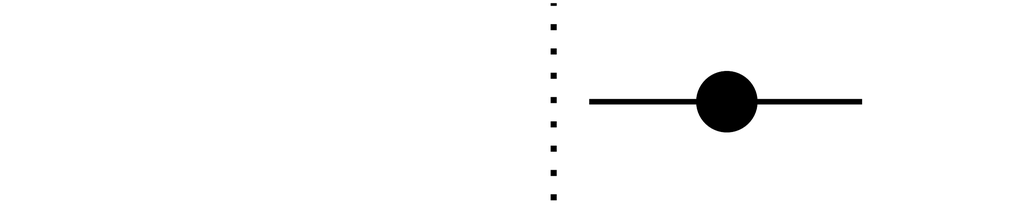

1

300

1.2 (0.44, 3.0)

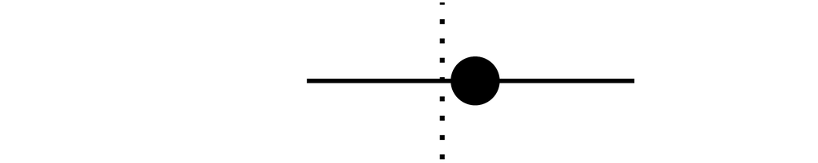

htn

1

660

1.8 (1.0, 3.2)

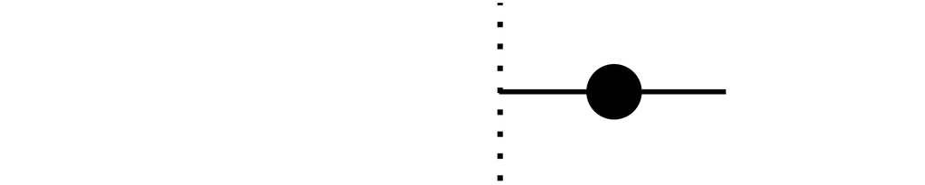

0

150

1.8 (0.49, 6.3)

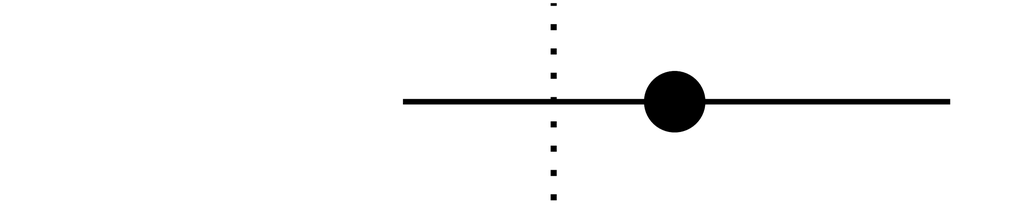

alcohol

1

230

0.63 (0.22, 1.7)

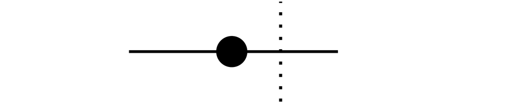

0

590

2.7 (1.5, 5.0)

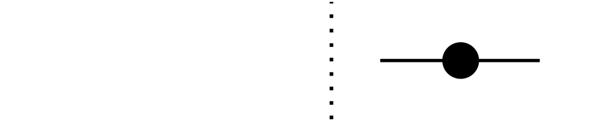

NA

NA

NA

NA (NA, NA)

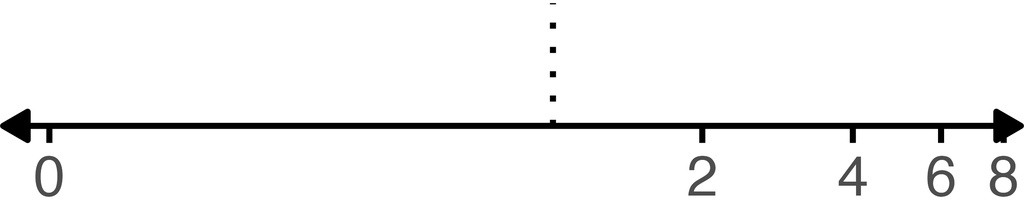

Next steps:

- Find agreement in key results and figures
- Identify main finding
- Complete discussion section

# October 10, 2022

**AF Registry**

Status:

- Current [overview](https://github.com/asshah4/aflubber/R/af_ablation_recurrence.html)
- Not yet powered
- Will need to revise out approach

# October 2, 2022

**AF Registry**

- Current number: 219
- Recurrence rate: 46%
- Death = 12
- MACE = 70 (including repeats)

[figure not shown]

GIS-based MAP of right atrium for mapping and localization purposes for publications.

# September 26, 2022

## AF Registry

**Analysis**

- Genetic analysis in PLINK complete
- Models are set up for analysis once data intake is done

**Status**

# September 12, 2022

## AF Registry

REDCap data dictionary is finalized. Next steps are:

1. Data entry for outcomes
2. Finalization of new patients to add from AF ablation registry

## Genetics

Currently able to:

- Format large SNP data sets into appropriate tables
- Utilize `PLINK` and `MERLIN` to process Chen’s genetics data
- Run from R to help analyze findings

Next steps:

- Confirm ancestry (for practice) percent likelihood
- Then, once outcome data is complete, analyze differences by race

Analytical methods:

- Time to binary outcome of recurrence
- Recurrent event analysis for AF recurrence
- Can revise with Bayesian modeling in `STAN` as well

# August 22, 2022

## AF Registry

**Status**

- REDCap is in progress
- Have an additional list of registry patients that may/may not have had ablation

**Next Steps**

1. Complete 100 REDCap patients
2. Identify 300 patients that have potentially had ablation

## CARTO Maps

- Ablation quantification
- Activation mapping
- EGM annotation
- Voltage mapping
- Conduction velocity
- Earliest/latest activation
- Geometry data

# August 15, 2022

**UIC-wide data summary**

- N ~ XXX had ablation
- Date range from >= 2010

**AF registry data**

- N=~300 had ablation
- Date range from >= 2010

**Next Steps**

1. Generate list of MRN for data collection
2. Use new REDCap to obtain ECG/ablation data
3. Run preliminary analysis on first 100 patients
4. Consider expansion to JBVA/ACMC data

# August 1, 2022

## AF Registry

Consider additional variables:

- Recurrent events and adjudication (HF, cardiac admission, MACE)
- Holter/ECG data and repeat collection (P-wave morphology, Wilson’s vector gradient, amplitude of AF waves “coarseness”)

Will check with the MESA and ARIC data base on how repeat events were defined.

## Murine EP Studies

[figure not shown]

## Human EP Studies

[figure not shown]

# July 25, 2022

## Forest Plots

```r
# Forest Plots
library(volundr)
m <- rx(
    Petal.Length ~ X(Sepal.Length) + Petal.Width + S(Species),
    label = list(
        Petal.Length ~ "Length of Petals",
        Species ~ "Genus of the Flower"
    ),
    pattern = "direct"
    ) |>
    fmls(order = 2) |>
    fit(.fit = lm,
            data = iris,
            archetype = TRUE) |>
    mdls()
```

```r
tbl <- tbl_forest( #<<
    object = m,
    formula = Petal.Length ~ Sepal.Length,
    vars = "Species",
    columns = list(
        beta ~ "Estimate",
        conf ~ "95% Confidence Interval",
        n ~ "Number of Samples"
    ),
    axis = list(
        lim ~ c(0, 3),
        breaks ~ c(0, 1, 2),
        lab ~ "ß (95% CI)",
        title ~ "Petal Length by Sepal Length"
    )
)
```

A simple way to make sub-group analysis Forest plots, working on improving customization.

# July 18, 2022

## AF Registry

The AF registry is described [here](https://asshah4.github.io/aflubber). Current issues:

1. Data quality - consistency between reviewers
2. Missingness - decisions on acceptable thresholds
3. Variable selection - echo findings, EP studies, medications, labs, symptoms
4. Management - REDCap, shared excel sheet
5. Adjudication/review - outcomes, clinical follow-up length

Stress Epidemiology, Arrhythmia Mechanisms, Clinical, Computational Neurocardiology